# Two Sample T-Test in R (Pooled)

Merrick Fanning

16/04/2022

### Outcomes

This tutorial will teach you how to confuct a pooled two sample t-test in R. This procedure tests the following hypothesis:

$H_0: \mu_1=\mu_2$

$H_0: \mu_1\neq\mu_2$

In order to run this test we require the following:  
- Random Samples: Each sample should be collected randomly  
- Idependence: Observations and samples should be independent of each other  
- Normality: Require approximatley normal data (tested with Anderson Darling test of significance), or samples of 30 or greater (so that the central limit theorem applies).

First I will load required packages and dataset

```r
library(ggplot2)
library(tidyverse)
library(car)
library(mosaic)
library(nortest)
dat <- read.csv('PooledT.csv')
```

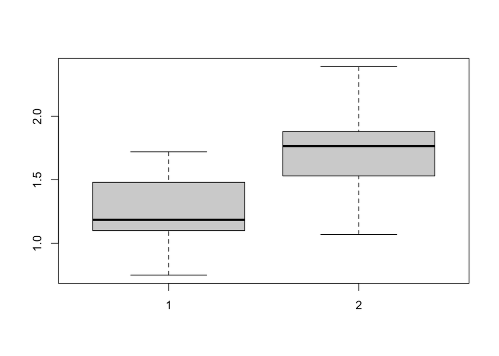

```r
boxplot(dat$conventional, dat$organic)
```

Looking at the boxplots you can see that organic avocadoes look like they typically have higher average prices. The purpose of our two sample t-test is to determine if the difference is statistically significant. It is reasonable to suspect that organic avocados would have higher prices than conventional so we will use a one tailed hypothesis:  
$H_0: \mu_{conv.} = \mu_{org.}$ or $H_0: \mu_{conv.} -\mu_{org.} = 0$  
$H_0: \mu_{conv.} < \mu_{org.}$ or $H_0: \mu_{conv.} - \mu_{org.} < 0$

### 1. Check Normality

First to determine which test is most appropriate noramlity of the samples must be checked. If the samples are roughly normal we assume that the parent population they come from is approximately normal. Here normality is examined in two different ways:

1. **Histogram of sample data:** Looking to see if the data is roughly symmetric and free from outliers.
2. **Anderson Darling test for normality:** This is a significance test with the following hypothesis:  
   $H_0:$ The data follow a normal distribution.  
   $H_A:$ The data do not follow a normal distribution (null hypothesis is false)

Results are shown below

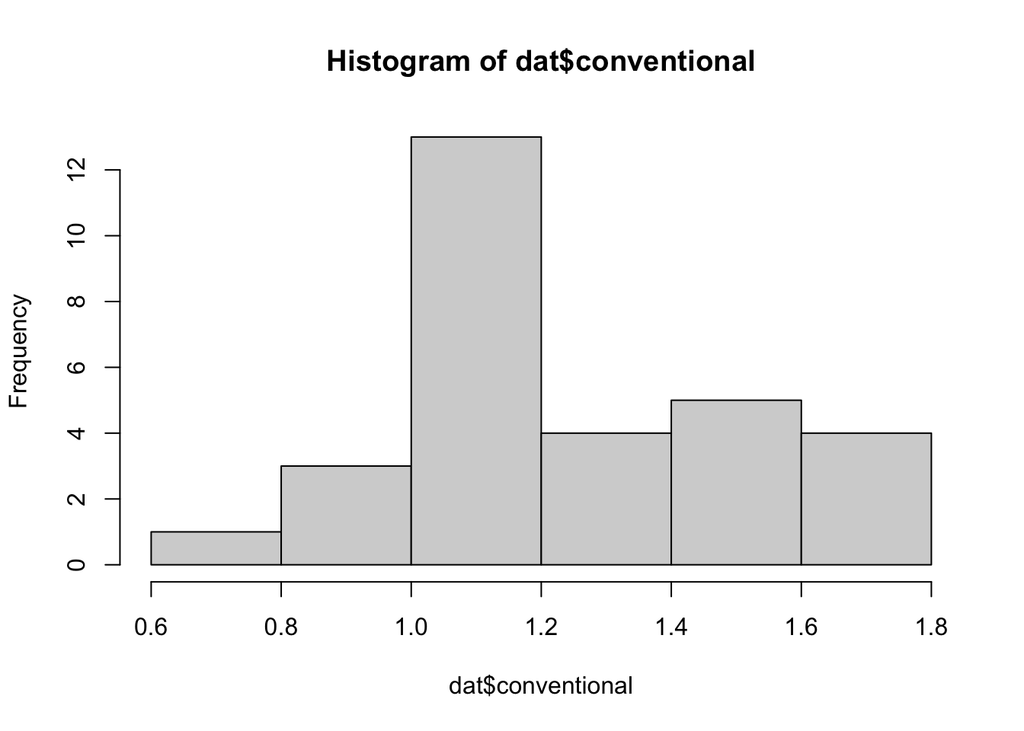

```r
## CONVENTIONAL NORMALITY
hist(dat$conventional) # No Skew or strong outliers
```

```r
ad.test(dat$conventional) # Fail to reject H_0, assume normal
```

```
##
##  Anderson-Darling normality test
##
## data:  dat$conventional
## A = 0.54784, p-value = 0.1454
```

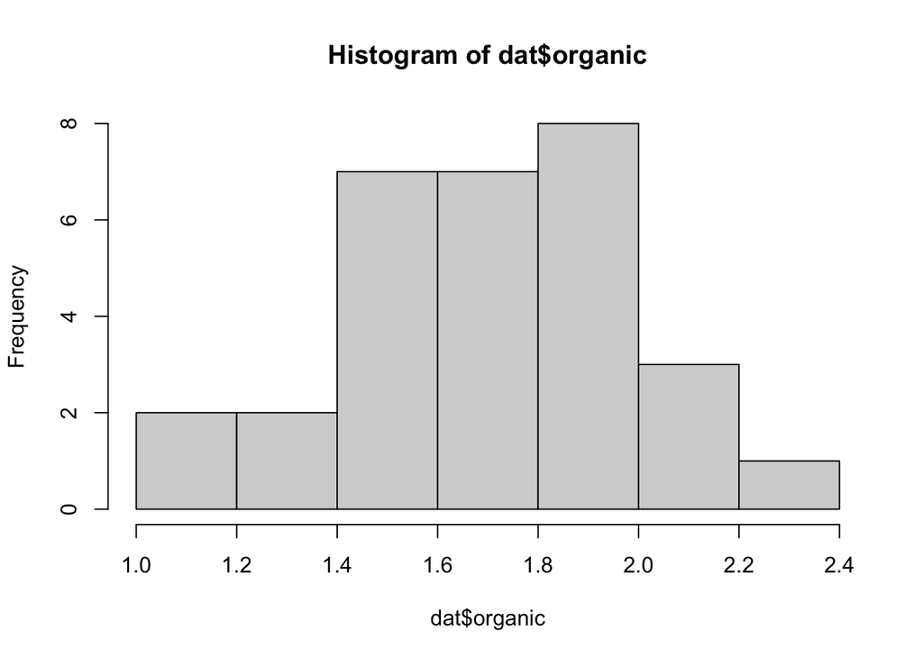

```r
## ORGANIC NORMALITY
hist(dat$organic) # No Skew or strong outliers
```

```r
ad.test(dat$conventional) # Fail to reject H_0, assume normal
```

[output not shown]

[output not shown]

### 2. Check Equal Variance (Homoscedasticity)

Once we confirm both samples are roughly normal we know we are using a parametric test. Since our samples are independent we will be doing either a pooled t-test (assumes equal variance) or a non-pooled t-test (assumes non-equal variance). We decide by comparing the variances of the two samples. Varinaces are compared below in two different ways:

1. **Examining boxplots:** We can eyeball the differences in spread of the two samples to compare variance.
2. **Levene’s test for equal variance**: This tests the following hypothesis:  
   $H_0: \sigma^2_1=\sigma^2_2=\cdots=\sigma^2_n$  
   $H_A:$ At least one $\sigma^2$ differs

Results are shown below:

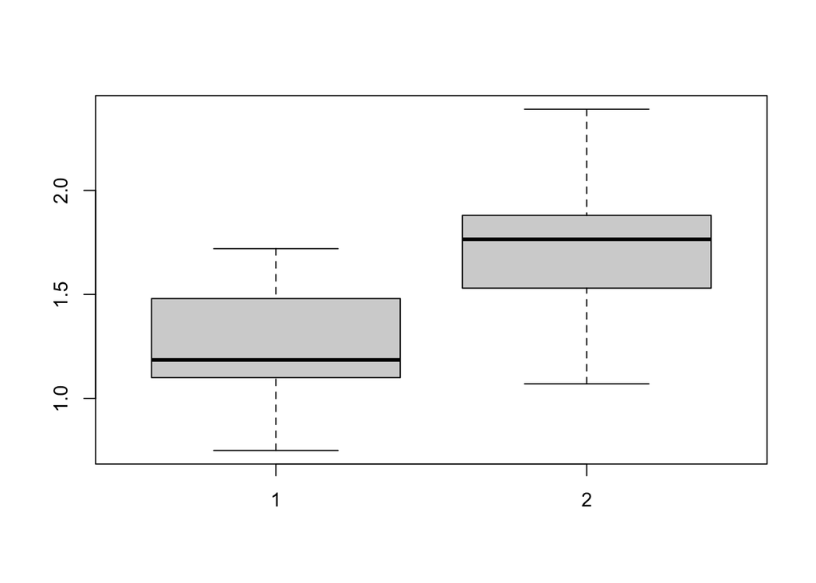

```r
boxplot(dat$conventional, dat$organic) # The spread of the two samples looks similar
```

```r
# Levenes test takes in stacked data
stacked <- stack(dat) # stack data
leveneTest(values~ind, data=stacked) # Run levenes test on stacked data p>0.05
```

```
## Levene's Test for Homogeneity of Variance (center = median)
##       Df F value Pr(>F)
## group  1   0.644 0.4255
##       58
```

### 3. Run Test:

After confirming variances are similar, we use a pooled t-test.

```r
t.test(dat$conventional, dat$organic, alternative="less", var.equal=TRUE) # p<0.05 so difference is significant.
```

```
##
##  Two Sample t-test
##
## data:  dat$conventional and dat$organic
## t = -6.5183, df = 58, p-value = 9.396e-09
## alternative hypothesis: true difference in means is less than 0
## 95 percent confidence interval:
##        -Inf -0.3462508
## sample estimates:
## mean of x mean of y
##  1.256667  1.722333
```

### 4. Conclusion

We reach our conclusion. Assuming that the null hypothesis is true (there is no difference in the true average prices for conventional and organic avocados) there is a roughly 0 probability of observing a test statistic of $-6.5183$ or lower. This is very condemining evidence against $H_0$.

Since $p$-value $<\alpha=0.05$ we reject $H_0$ and assume there is a difference in the average prices of conventional and organic avocados.